# R Data files, plot and modeling

Qi Zhang (including materials from Dr. Ryan Tibshirani’s class at CMU)

August 01, 2021

#### Merging data

Suppose you have two data frames X, Y, and you want to combine them. How you will do it depends on what you want to combine, and there are several cases.

- 1. Simplest case: the rows of the data frames represent exactly the same units, in the same order. You want all columns from both. Then you just use, data.frame(X,Y)
- 2. The rows of the data frames represent exactly the same units, in the same order. But you only want some columns from both. Let colX and colY represent the vectors of column names of the columns of X and Y that you want to combine, then you just use data.frame(X[,colX],Y[,colY])
- 3. The rows of the data frames represent exactly the same units, but in different order. Put them in the same order, with order(). Alternatively, use merge()
- 4. The hard case: there are units in common, but also unique units to X or Y. It would be hard to line up.

You need to decide whether you only want the units that are in common in both data frames, or also want to keep the units unique to X or Y. If the latter, you also need to decide how to present the missing values.

Example: County level Covid data

Suppose we are interested in investigating how the demographics of a county in US affect their COVID cases and death on a given date (say, June 3rd 2021).

NY Times has county level covid data, but no information about the demographics in the counties. Census.org has demographics data, but not covid cases. We need to merge these datasets to perform any analysis.

In this example, you will see some technics in text manipulation and data cleaning. While they are useful in practice, you are not required to know how to use them for this course. However, when you are merging data in practice, similar issues may arise. We first merge the two Census datasets.

```r
dir.data = "D:\\Dropbox\\courses\\stat_computing\\data\\"
setwd(dir.data)
census2018dp02 <- read.csv('ACSDP5Y2018.DP02_data_with_overlays_2020-06-12T230404.csv',header=T,skip=1)
census2018dp05 <- read.csv('ACSDP5Y2018.DP05_data_with_overlays_2020-06-12T095532.csv',header=T,skip=1)
dim(census2018dp02)
```

```
## [1] 3220  610
```

```r
dim(census2018dp05)
```

```
## [1] 3220  358
```

```r
census2018dp02[1,1:5]
```

```
##               id    Geographic.Area.Name
## 1 0500000US01001 Autauga County, Alabama
##   Estimate..HOUSEHOLDS.BY.TYPE..Total.households
## 1                                          21115
##   Margin.of.Error..HOUSEHOLDS.BY.TYPE..Total.households
## 1                                                   383
##   Percent.Estimate..HOUSEHOLDS.BY.TYPE..Total.households
## 1                                                  21115
```

```r
census2018dp05[1,1:5]
```

```
##               id    Geographic.Area.Name
## 1 0500000US01001 Autauga County, Alabama
##   Percent.Margin.of.Error..SEX.AND.AGE..Total.population..65.years.and.over..Female
## 1                                                                               0.4
##   Estimate..SEX.AND.AGE..Total.population..65.years.and.over..Sex.ratio..males.per.100.females.
## 1                                                                                          76.5
##   Margin.of.Error..SEX.AND.AGE..Total.population..65.years.and.over..Sex.ratio..males.per.100.females.
## 1                                                                                                  1.2
```

```r
identical(census2018dp02$Geographic.Area.Name,census2018dp05$Geographic.Area.Name)
```

```
## [1] TRUE
```

The rows in the two Census datasets represent the same units in the same order.

```r
census2018 <- data.frame(census2018dp02,census2018dp05[,-(1:2)])
dim(census2018)
```

```
## [1] 3220  966
```

```r
census2018[1,1:5]
```

```
##               id    Geographic.Area.Name
## 1 0500000US01001 Autauga County, Alabama
##   Estimate..HOUSEHOLDS.BY.TYPE..Total.households
## 1                                          21115
##   Margin.of.Error..HOUSEHOLDS.BY.TYPE..Total.households
## 1                                                   383
##   Percent.Estimate..HOUSEHOLDS.BY.TYPE..Total.households
## 1                                                  21115
```

```r
tail(census2018,1)[1:10]
```

```
##                  id         Geographic.Area.Name
## 3220 0500000US72153 Yauco Municipio, Puerto Rico
##      Estimate..HOUSEHOLDS.BY.TYPE..Total.households
## 3220                                           null
##      Margin.of.Error..HOUSEHOLDS.BY.TYPE..Total.households
## 3220                                                  null
##      Percent.Estimate..HOUSEHOLDS.BY.TYPE..Total.households
## 3220                                                   null
##      Percent.Margin.of.Error..HOUSEHOLDS.BY.TYPE..Total.households
## 3220                                                          null
##      Estimate..HOUSEHOLDS.BY.TYPE..Total.households..Family.households..families.
## 3220                                                                         null
##      Margin.of.Error..HOUSEHOLDS.BY.TYPE..Total.households..Family.households..families.
## 3220                                                                                null
##      Percent.Estimate..HOUSEHOLDS.BY.TYPE..Total.households..Family.households..families.
## 3220                                                                                 null
##      Percent.Margin.of.Error..HOUSEHOLDS.BY.TYPE..Total.households..Family.households..families.
## 3220                                                                                        null
```

We remove the columns for the Margin of Error of the Census estimates, and Puerto Rico for simplicity of the example.

```r
ix.me <- grepl('Margin.of.Error',names(census2018))
sum(ix.me)
```

```
## [1] 482
```

```r
census2018.pe <- census2018[!grepl('Puerto Rico',census2018$Geographic.Area.Name),!ix.me]
dim(census2018.pe)
```

```
## [1] 3142  484
```

The covid dataset from NY Times

```r
setwd(dir.data)
covid <- read.csv('us-counties-recent.csv')
dim(covid)
```

```
## [1] 97399     6
```

```r
head(covid)
```

```
##         date  county   state fips cases deaths
## 1 2021-05-05 Autauga Alabama 1001  6914    108
## 2 2021-05-05 Baldwin Alabama 1003 21035    307
## 3 2021-05-05 Barbour Alabama 1005  2307     56
## 4 2021-05-05    Bibb Alabama 1007  2604     63
## 5 2021-05-05  Blount Alabama 1009  6635    136
## 6 2021-05-05 Bullock Alabama 1011  1229     41
```

```r
tail(covid)
```

```
##             date     county   state  fips cases deaths
## 97394 2021-06-03   Sublette Wyoming 56035   796      7
## 97395 2021-06-03 Sweetwater Wyoming 56037  4558     39
## 97396 2021-06-03      Teton Wyoming 56039  3785      9
## 97397 2021-06-03      Uinta Wyoming 56041  2287     13
## 97398 2021-06-03   Washakie Wyoming 56043   923     26
## 97399 2021-06-03     Weston Wyoming 56045   655      6
```

The information of each county on each of the last 30 days are recorded. We will focus on the information on a particular date, and remove Virgin Islands, Northern Mariana Islands and Puerto Rico for simplicity.

```r
covid0603 <- covid[covid$date=='2021-06-03',]
dim(covid0603)
```

```
## [1] 3247    6
```

Remove the data with unknown county, and the data for Virgin Islands, Northern Mariana Islands and Puerto Rico.

```r
covid0603.county <- covid0603[covid0603$county!='Unknown'&!is.element(covid0603$state,c('Virgin Islands','Northern Mariana Islands','Puerto Rico')),]
dim(covid0603.county)
```

```
## [1] 3138    6
```

The rows of the covid data and the census data represent mostly the same units, potentially with different order.

But there must be some differences in the units that the row represents, because they have different numbers of rows.

Let us find out these differences during the following process of building a common variable that matches the rows of the two data frames.

We need to find a variable that is common to the two data frames, and is able to uniquely identify the rows in each column.

e.g., if this column is called “key”, and X$key[2] == Y$key[5], then the 2nd row of X and the 5th row of Y represent the same unit(subject).

One choice of such could be a common variable (by nature but not necessarily by name) that has a unique value for each unit.

When such key is unavailable directly, we can define one.

```r
id.region.covid <-  paste(covid0603.county$county,covid0603.county$state,sep='_')
id.region.census <- gsub(' County, ','_',census2018.pe$Geographic.Area.Name)

head(id.region.covid)
```

```
## [1] "Autauga_Alabama" "Baldwin_Alabama" "Barbour_Alabama" "Bibb_Alabama"
## [5] "Blount_Alabama"  "Bullock_Alabama"
```

```r
head(id.region.census)
```

```
## [1] "Autauga_Alabama" "Baldwin_Alabama" "Barbour_Alabama" "Bibb_Alabama"
## [5] "Blount_Alabama"  "Bullock_Alabama"
```

Let us see how many matches we have found.

```r
length(intersect(id.region.covid,id.region.census))
```

```
## [1] 3001
```

Let us investigate the differences. setdiff(A,B) outputs the values that are in vector A, but not B

```r
id.census.only <- sort(setdiff(id.region.census,id.region.covid))
id.covid.only <- sort(setdiff(id.region.covid,id.region.census))
length(id.census.only)
```

```
## [1] 141
```

```r
length(id.covid.only)
```

```
## [1] 137
```

```r
head(id.census.only,10)
```

```
##  [1] "Acadia Parish, Louisiana"           "Aleutians East Borough, Alaska"
##  [3] "Aleutians West Census Area, Alaska" "Alexandria city, Virginia"
##  [5] "Allen Parish, Louisiana"            "Anchorage Municipality, Alaska"
##  [7] "Ascension Parish, Louisiana"        "Assumption Parish, Louisiana"
##  [9] "Avoyelles Parish, Louisiana"        "Baltimore city, Maryland"
```

```r
head(id.covid.only,10)
```

```
##  [1] "Acadia_Louisiana"                  "Aleutians East Borough_Alaska"
##  [3] "Aleutians West Census Area_Alaska" "Alexandria city_Virginia"
##  [5] "Allen_Louisiana"                   "Anchorage_Alaska"
##  [7] "Ascension_Louisiana"               "Assumption_Louisiana"
##  [9] "Avoyelles_Louisiana"               "Baltimore city_Maryland"
```

You may realized that many of them because some counties are not called XX County. So the true separator between county name and the sate name is “,” instead of " County," We will substitute “,” with "_“, and remove words such as”County“,”Parish", and white space.

```r
id.region.covid <-  gsub(' ','',gsub('Municipality','',paste(covid0603.county$county,covid0603.county$state,sep='_')))
id.region.census <- gsub(' ','',gsub('Municipality','',gsub('Parish','',gsub('County','',gsub(',','_',census2018.pe$Geographic.Area.Name)))))

length(intersect(id.region.covid,id.region.census))
```

```
## [1] 3132
```

```r
id.census.only <- sort(setdiff(id.region.census,id.region.covid))
id.covid.only <- sort(setdiff(id.region.covid,id.region.census))
length(id.census.only)
```

```
## [1] 10
```

```r
length(id.covid.only)
```

```
## [1] 6
```

```r
#head(id.census.only)
#head(id.covid.only)
id.census.only
```

```
##  [1] "BristolBayBorough_Alaska"       "Bronx_NewYork"
##  [3] "Doï¿½aAna_NewMexico"            "Hoonah-AngoonCensusArea_Alaska"
##  [5] "Kings_NewYork"                  "LakeandPeninsulaBorough_Alaska"
##  [7] "NewYork_NewYork"                "Queens_NewYork"
##  [9] "Richmond_NewYork"               "YakutatCityandBorough_Alaska"
```

```r
id.covid.only
```

```
## [1] "BristolBayplusLakeandPeninsula_Alaska"
## [2] "DoÃ±aAna_NewMexico"
## [3] "Joplin_Missouri"
## [4] "KansasCity_Missouri"
## [5] "NewYorkCity_NewYork"
## [6] "YakutatplusHoonah-Angoon_Alaska"
```

We now find that most of these differences are due to difference in measurement unit: Covid data report NYC as a whole, while census data have entires for each county separately. Similarly, Covid data combine parts of Alaska together. Since such discrepancy makes them incomparable, and there are not many, we may want to remove them from the merged data. The county in New Mexico seems to be due to encoding error. I do not know what is happening to the two counties in Missouri, because there is no potential match in census data, and every county in census data are matched by something else in the covid data.

We may be able to save these data points if we are willing to spend more time on the context of the data.

For example, maybe Kansas City and the county it is in produce separate reports of covid cases. We may be also able to create NYC level census data that match NYC covid data by adding the county level data within NYC border.

We need to be very careful when deciding what to delete from the dataset. Sometimes deleting data points, even just a few, may bias the downstream analysis. Selection bias occurs when the data points excluded are not a random sample of all data points, and the exclusion probability confound with the analysis goal.

For now, let us assume that we can safely remove these points, and only save the county in New Mexico. What is the county in New Mexico. I found on google that it is Do$\tilde{n}$a Ana, and the weired string may be due to the coding failure of $\tilde{n}$ when compiling the dataset.

```r
id.region.census[id.region.census=="Do??????aAna_NewMexico"] <- 'DonaAna_NewMexico'
id.region.covid[id.region.covid=="Do????aAna_NewMexico"] <- 'DonaAna_NewMexico'
```

Now we add this new column to both data frames so that they ahve a common column.

```r
covid0603.county$region_id <- id.region.covid
census2018.pe$region_id <- id.region.census
```

merge() function merge two data frames, and match the rows by the argument “by”. If you set all=F, the units unique to each data frame will be removed. Otherwise, (some of) them will be kept.

```r
dt.covid.census <- merge(x=covid0603.county,y=census2018.pe,by='region_id',all=F)
dim(dt.covid.census)
```

```
## [1] 3132  491
```

The merge() function tries to merge two data frames according to common columns, as in: merge(x, y, by.x=“SomeXCol”, by.y=“SomeYCol”), to join two data frames x, y, by matching the columns ???SomeXCol??? and ???SomeYCol??? Default (no by.x, by.y specified) is to match all columns with common names Output will be a new data frame that has all the columns of both data frames

if all.x=T, all units unique to data frame x will be kept. These units are not in data frame y, so their values in the columns that are unique to y will be missing values.

#### Practice

Note that covid.college also include the county and state it each college is in.

For each college, we want to add the covid information of the county that it is in from covid0603.county.

For simplicity, we will focus on the New England states Connecticut, Maine, Massachusetts, New Hampshire, Rhode Island, and Vermont.

1. You can first create a data frame covid0603.ne by extracting the rows of covid0603.county whose state is one of the New England states, and covid.college.ne by extract the rows of covid.college in the New England states. What are the dimensions of these two data frames.
2. Then, please merge covid.college.ne and covid0603.ne. We want to keep every row in covid.college.ne. But we are not interested in the counties with no college. Let us call the final output covid.college.w.county.ne. What is the dimension of this data frame? Can you guess how merge function handles it when one row of Y can be mapped to multiple rows of X?

## Visualization

Base R has a set of powerful plotting tools. An overview:

plot(): generic plotting function

points(): add points to an existing plot

lines(), abline(): add lines to an existing plot

text(), legend(): add text to an existing plot

rect(), polygon(): add shapes to an existing plot

hist(), image(): histogram and heatmap

heat.colors(), topo.colors(), etc: create a color vector

density(): estimate density, which can be plotted

contour(): draw contours, or add to existing plot

curve(): draw a curve, or add to existing plot

#### Scatter plot

To make a scatter plot of one variable versus another, use plot()

```r
n = 50
set.seed(0)
x = sort(runif(n, min=-2, max=2))
y = x^3 + rnorm(n)
plot(x, y)
```

[output not shown]

Plot type: The type argument controls the plot type. Default is p for points; set it to l for lines

```r
plot(x, y, type="p")
```

[output not shown]

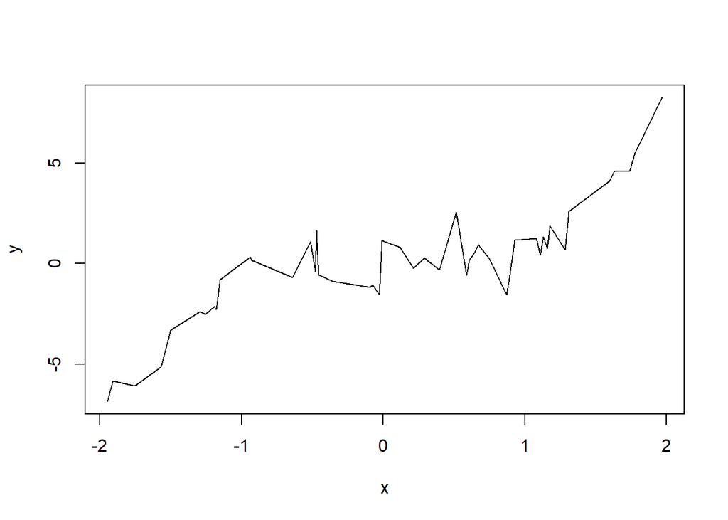

```r
plot(x, y, type="l")
```

type argument can also be b or o, for both points and lines Labels: The main argument controls the title; xlab and ylab are the x and y labels

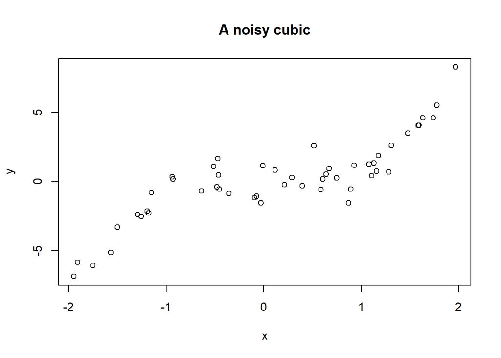

```r
plot(x, y, main="A noisy cubic") # Note the default x and y labels
```

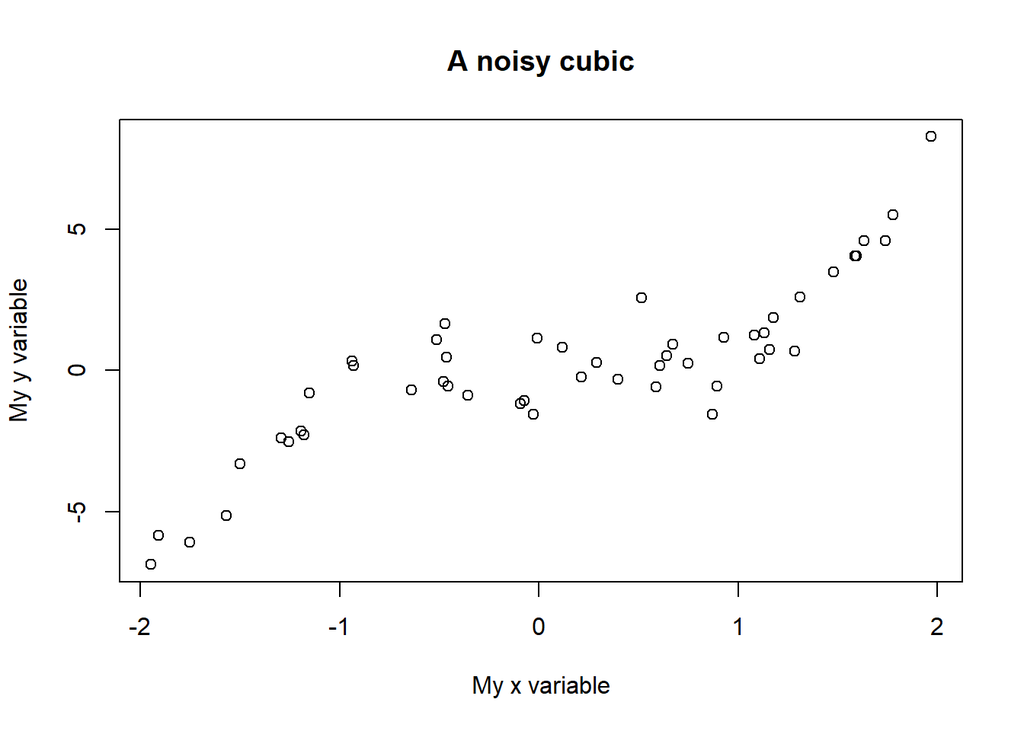

```r
plot(x, y, main="A noisy cubic", xlab="My x variable", ylab="My y variable")
```

Point type: Use the pch argument to control point type

```r
plot(x, y, pch=21) # Empty circles, default
```

[output not shown]

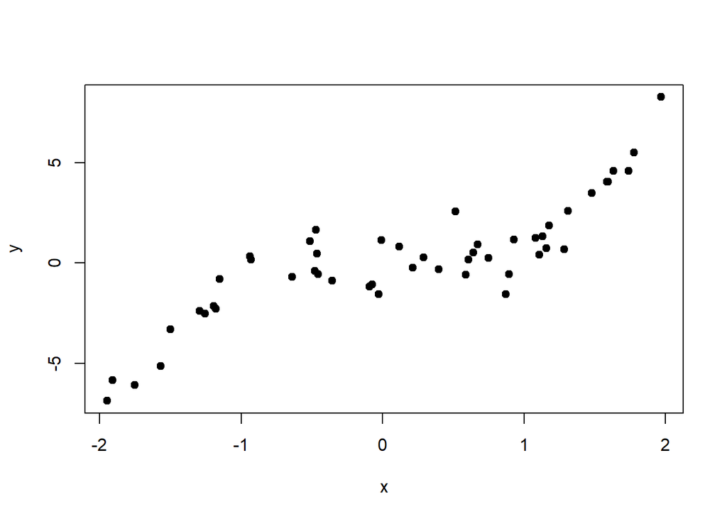

```r
plot(x, y, pch=19) # Filled circles
```

For more options, see https://stat.ethz.ch/R-manual/R-patched/library/graphics/html/points.html Line type: Use the lty argument to control the line type, and lwd to control the line width

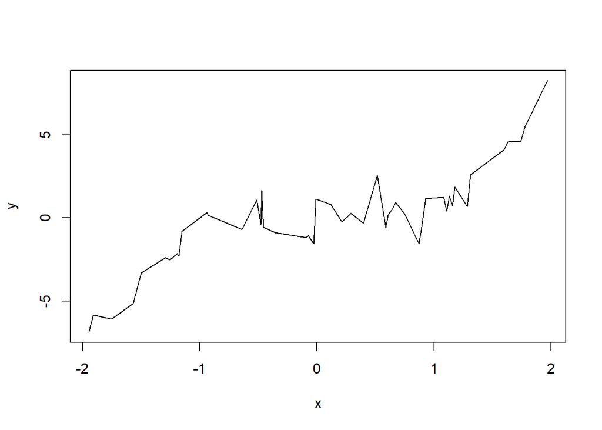

```r
plot(x, y, type="l", lty=1, lwd=1) # Solid line, default width
```

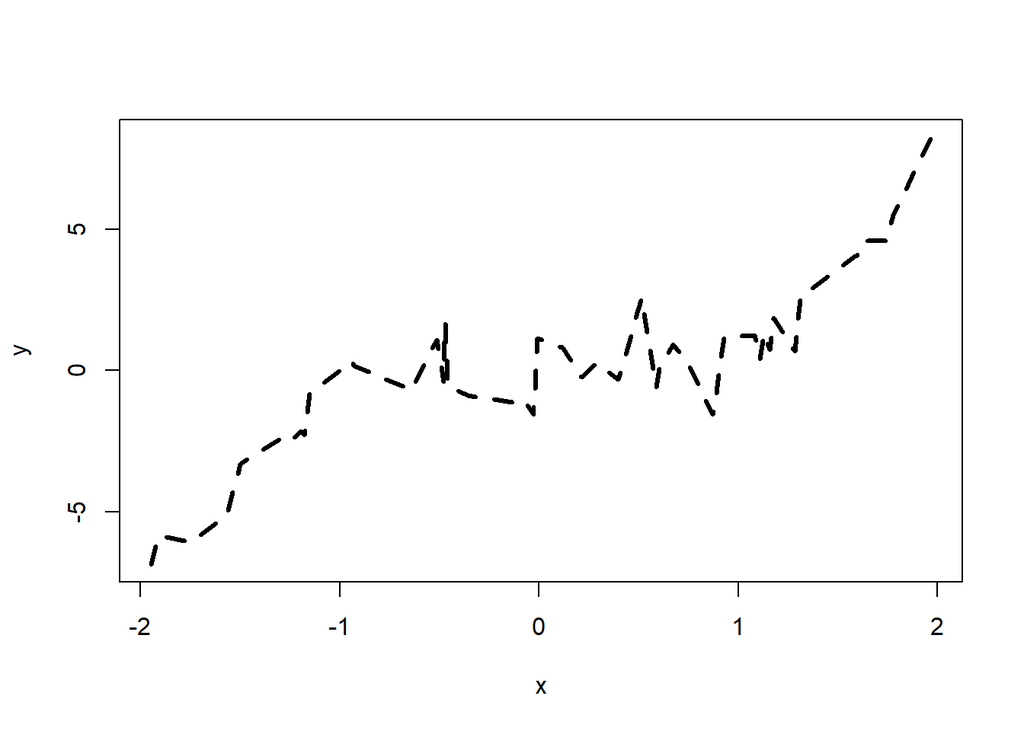

```r
plot(x, y, type="l", lty=2, lwd=3) # Dashed line, 3 times as thick
```

Color:

Use the col argument to control the color. Can be: An integer between 1 and 8 for basic colors

A string for any of the 657 available named colors

The function colors() returns a string vector of the available colors

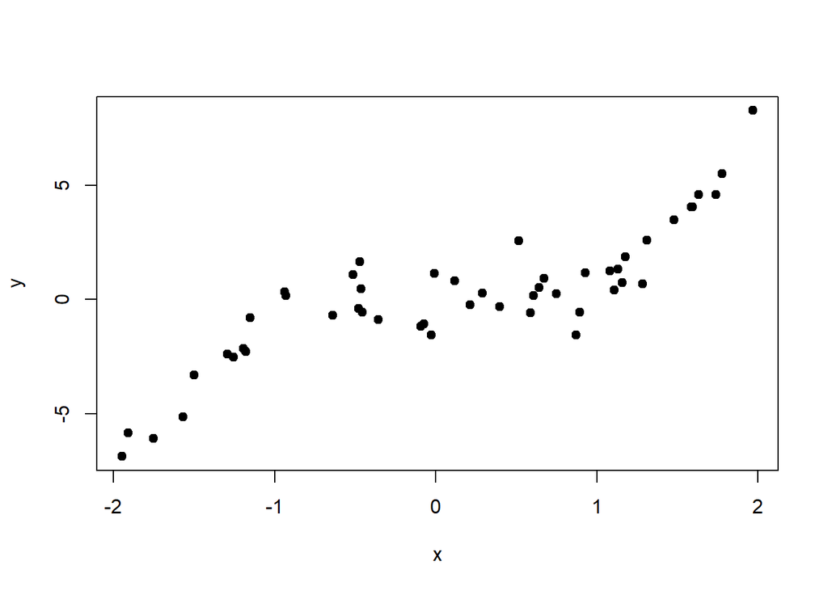

```r
plot(x, y, pch=19, col=1) # Black, default
```

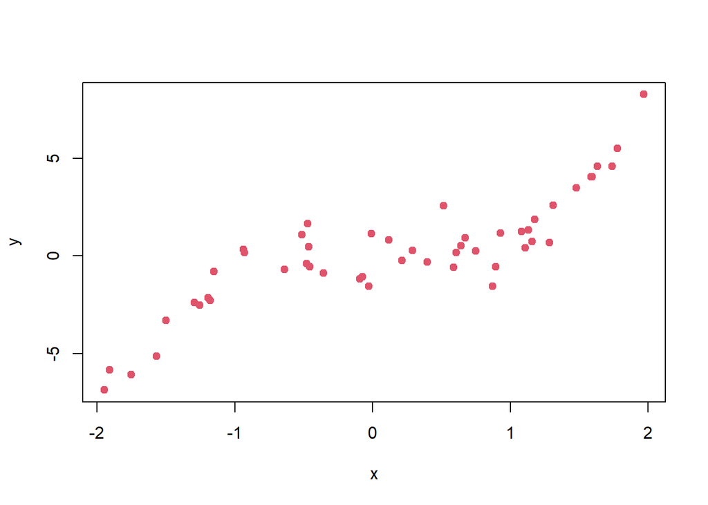

```r
plot(x, y, pch=19, col=2) # Red
```

Multiple plots:

To set up a plotting grid of arbitrary dimension, use the par() function, with the argument mfrow.

Note: in general this will affect all following plots! (Except in separate R Markdown code chunks)

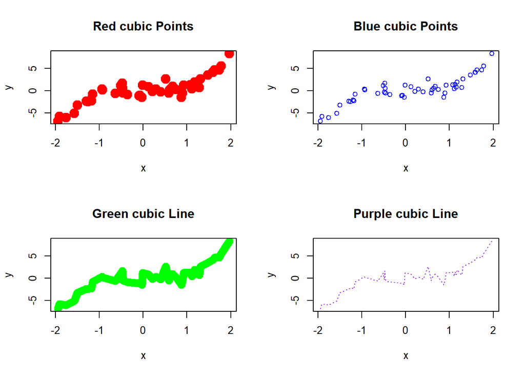

```r
par(mfrow=c(2,2)) # Grid elements are filled by row
plot(x, y, main="Red cubic Points", pch=20,cex=3,col="red")
plot(x, y, main="Blue cubic Points", pch=21, col="blue")
plot(x, y, main="Green cubic Line", type = 'l',lty=1,lwd=10, col="green")
plot(x, y, main="Purple cubic Line", type='l',lty=3, lwd=1,col="purple")
```

```r
#par()
#par(mfrow=c(1,1))
#dev.off()
```

Margin

Default margins in R are large (and ugly); to change them, use the par() function, with the argument mar.

Note: in general this will affect all following plots! (Except in separate R Markdown code chunks ???)

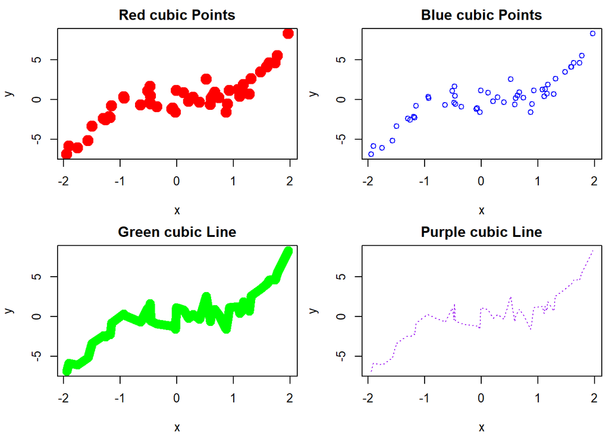

```r
par(mfrow=c(2,2), mar=c(4,4,2,0.5))
plot(x, y, main="Red cubic Points", pch=20,cex=3,col="red")
plot(x, y, main="Blue cubic Points", pch=21, col="blue")
plot(x, y, main="Green cubic Line", type = 'l',lty=1,lwd=10, col="green")
plot(x, y, main="Purple cubic Line", type='l',lty=3, lwd=1,col="purple")
```

Saving plots

Use the pdf() function to save a pdf file of your plot, in your R working directory. Use getwd() to get the working directory, and setwd() to set it

```r
setwd(dir.data)
getwd()
```

```
## [1] "D:/Dropbox/courses/stat_computing/data"
```

```r
pdf(file="noisy_cubics.pdf", height=7, width=7) # Height, width are in inches
par(mfrow=c(2,2), mar=c(4,4,2,0.5))
plot(x, y, main="Red cubic Points", pch=20,cex=3,col="red")
plot(x, y, main="Blue cubic Points", pch=21, col="blue")
plot(x, y, main="Green cubic Line", type = 'l',lty=1,lwd=10, col="green")
plot(x, y, main="Purple cubic Line", type='l',lty=3, lwd=1,col="purple")
graphics.off()
```

Also, use the jpg() and png() functions to save jpg and png files Adding to plots: you can draw a plot first, and then add more components to it. The main tools for this are:

points(): add points to an existing plot lines(), abline(): add lines to an existing plot text(), legend(): add text to an existing plot rect(), polygon(): add shapes to an existing plot You???ll get practice with this on lab. Pay attention to layers???they work just like they would if you were painting a picture by hand

#### Practice

1. Below is some code that is very similar to that from the lecture, but with one key difference. Please explain why does the `plot()` result with with `type="p"` look normal, but the `plot()` result with `type="l"` look abnormal, having crossing lines? Then modify the code below (hint: modify the definition of `x`), so that the lines on the second plot do not cross.

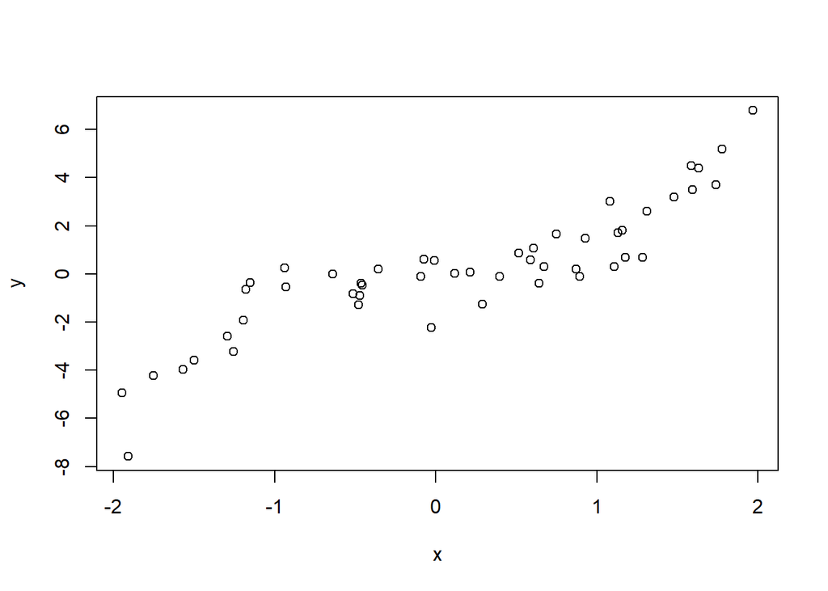

```r
n = 50
set.seed(0)
x = runif(n, min=-2, max=2)
y = x^3 + rnorm(n)
plot(x, y, type="p")
```

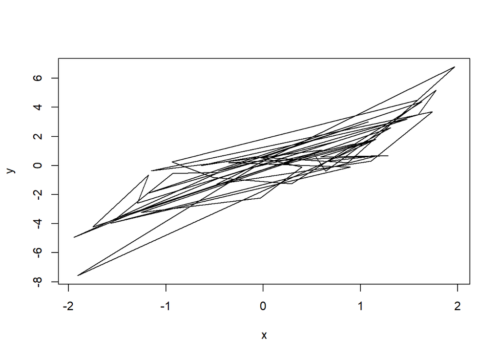

```r
plot(x, y, type="l")
```

2. The `cex` argument can used to shrink or expand the size of the points that are drawn. Its default value is 1 (no shrinking or expansion).

Values between 0 and 1 will shrink points, and values larger than 1 will expand points.

Plot `y` versus `x`, first with green filled circle and `cex` equal to 0.5, and then with purple empty circle and “cex” 3 (so, two separate plots). Give titles “Shrunken green filled circle”, and “Expanded purple empty circles”, to the plots, respectively.

3. The `xlim` and `ylim` arugments can be used to change the limits on the x-axis and y-axis, respectively. Each argument takes a vector of length 2, as in `xlim = c(-1, 0)`, to set the x limit to be from -1 to 0.

Plot `y` versus `x`, with the x limit set to be from -1 to 1, and the y limit set to be from -5 to 5. Assign x and y labels “Trimmed x” and “Trimmed y”, respectively.

4. The `pch` argument, recall, controls the point type in the display. In the lecture examples, we set it to a single number. But each of pch, col,cex can also be a vector, with one entry per point in the plot (recycle if shorter). So, e.g.,

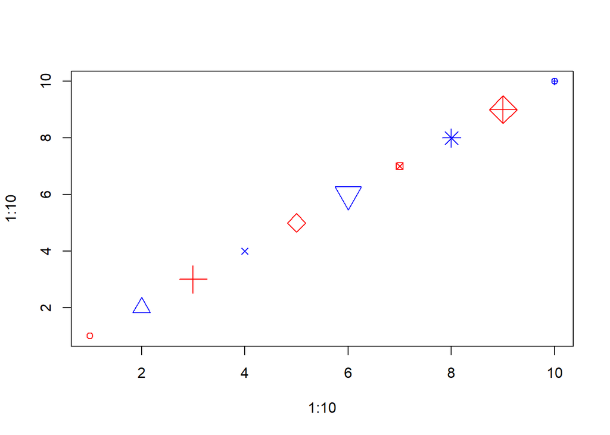

```r
plot(1:10, 1:10, pch=1:10,cex=1:3,col=c('red','blue'))
```

displays the first 10 point types with alternating sizes 1 to 3 and colors red and blue.

In the call to `lines()`, set the `col` and `lwd` arguments so that the line is drawn in red, with twice the normal thickness. Look carefully at your resulting plot. Does the red line pass overtop of or underneath the black empty circles? What do you conclude about the way R *layers* these additions to your plot? Then a blue dash line for x2, y2.

7. Starting with your solution code from the last question, add a legend to the bottom right corner of the the plot using `legend()`. The legend should display the text: “Cubic” and “Quadratic”, with corresponding symbols: an empty black circle with solid line and a filled blue circle with dash line, respectively.

Hint: it will help to look at the documentation for `legend()`.